# tidyr

## 1 Get started

Before you start, make sure to load the `tidyverse` package.

```r
library(tidyverse)
```

## 2 Let’s tidy some data sets

First, complete both tasks before you move to the extras.

**1. `relig_incom`**

Have a look at the `relig_income` data set that is included in tidyverse package. The data set contains the results of a survey asking people about their religion and income category.

What is not tidy about this data set? Can you fix it?

**2. `billboard`**

Have a look at the `billboard` data set that is included in the tidyverse package. The data set contains information about the chart rank of songs in the year 2000.

What is not tidy about this data set? Can you fix it?

## 3 Extras

- Check out the `values_drop_na` and `names_prefix` argument of `pivot_longer`. What does it do and how can you use it with the `billboard` data?
- This is a bit tricky: How would you have to change the `penguins` table if you wanted to make such a plot:

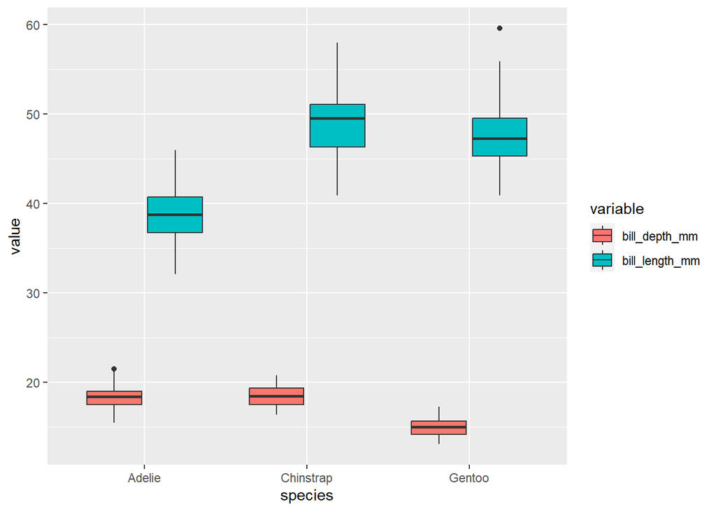

Hint: First use `dplyr` and only select the columns that you need for the plot. Then think about how to use `tidyr` to transform the data so it’s ready for `ggplot`